# Applied Machine Learning in Economics Problem set 5

Nasim Gholizadeh(nasimg2)

# Question 1 (concept)

We perform best subset, forward stepwise, and backward stepwise selection on a single data set. For each approach, we obtain p + 1 models, containing 0, 1, 2, . . . , p predictors. Explain your answers:

1. Which of the three models with k predictors has the smallest training RSS?
2. Which of the three models with k predictors has the smallest test RSS?
3. True or False:
1. The predictors in the k-variable model identified by forward stepwise are a subset of the predictors in the (k + 1)-variable model identified by forward stepwise selection.
2. The predictors in the k-variable model identified by backward stepwise are a subset of the predictors in the (k + 1)-variable model identified by backward stepwise selection.
3. The predictors in the k-variable model identified by backward stepwise are a subset of the predictors in the (k + 1)-variable model identified by forward stepwise selection.
4. The predictors in the k-variable model identified by forward stepwise are a subset of the predictors in the (k + 1)-variable model identified by backward stepwise selection.
5. The predictors in the k-variable model identified by best subset are a subset of the predictors in the (k + 1)-variable model identified by best subset selection.

# Answer 1

Best subset has the smallest training RSS with k predictors, because best subset considers all of the models considered by the stepwise selection methods.

We cannot say for sure. Best subset might overfit if n is relativly small compared to p. But for any particular testing set, either of them might be best.

True. At k+1, forward selection has added a new predictor to those at k.

True. At k, backward selection has deleted a predictor from those at k+1.

False. The models at any k for forward and backward selection do not necessarily have overlap.

False, for the same reasoning as in (iii).

False. Predictors used at k may be completely different from predictors used at k+1.

# Question 2 (concept)

For parts (a) through (c), indicate which of i. through iv. is correct. Justify your answer.

1. The lasso, relative to least squares, is:
1. More flexible and hence will give improved prediction accuracy when its increase in bias is less than its decrease in variance.
2. More flexible and hence will give improved prediction accuracy when its increase in variance is less than its decrease in bias.
3. Less flexible and hence will give improved prediction accuracy when its increase in bias is less than its decrease in variance.
4. Less flexible and hence will give improved prediction accuracy when its increase in variance is less than its decrease in bias.
2. Repeat (a) for ridge regression relative to least squares.
3. Repeat (a) for non-linear methods relative to least squares.

# Answer 2

3. Lasso’s solution can have a reduction in variance at the expense of small increase in bias while least squares estimates have high variance. Lasso can shrink coefficient estimates, removing non-essential variables for less variance and higher bias. The lasso is a more restrictive model, and thus it has the possibility of reducing overfitting and variance in predictions. As long as it does not result in too high of a bias due to its added constraints, it will outperform least squares.
3. Like Lasso, ridge can shrink the coefficient estimates, decreasing variance with higher bias. Ridge is less flexible than the least squares. The same reason as above.
2. Non-linear models are more flexible and have less bias than least squares.

# Question 3 (applied)

In this exercise, we will generate simulated data, and will then use this data to perform best subset selection. (Hint: To be able to reproduce your results, do not forget to set the seed in your randomization using the command set.seed().)

1. Use the rnorm() function to generate a predictor X of length n = 100, as well as a noise vector e of length n = 100.
2. Generate a response vector Y of length n = 100 according to the model Y = β0 + β1X + β2X^2 + β3X^3 + e, where β0, β1, β2, β3 are constants of your choice.
3. Use the regsubsets() function to perform (exhaustive or global) best subset selection in order to choose the best model containing the predictors X, X2, . . . , X10. What is the best model obtained according to Cp, BIC, and adjusted R^2? Show some plots to provide evidence for your answer, and report the coefficients of the best model obtained. Note you will need to use the data.frame() function to create a single data set containing both X and Y.
4. Repeat (c), using forward stepwise selection and also using backwards stepwise selection. How does your answer compare to the results in (c)?
5. Repeat (c), that is use the regsubsets() function to perform (exhaustive or global) best subset selection in order to choose the best model containing the predictors X, X2, . . . , X10. What is the best model obtained according to 10-fold cross-validation?

# Answer 3

```r
set.seed(1)
X <- rnorm(100)
e <- rnorm(100)
```

```r
B0 <- -4
B1 <- 3
B2 <- -2
B3 <- 1
Y <- B0 + B1*X + B2*X^2 + B3*X^3 + e
```

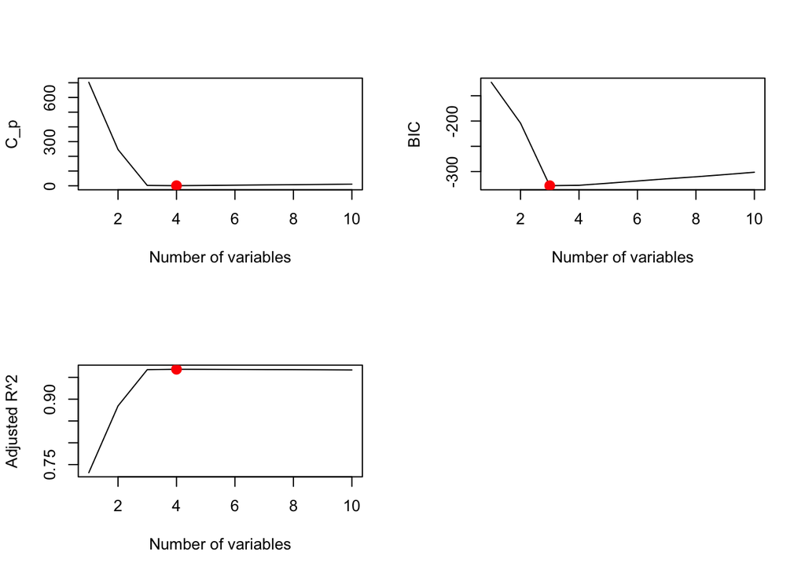

```r
library(leaps)
data.full = data.frame(Y, X)
regfit.full = regsubsets(Y~poly(X,10,raw=T), data=data.frame(Y,X), nvmax=10)
summary = summary(regfit.full)
par(mfrow=c(2,2))
plot(summary$cp, xlab ="Number of variables", ylab="C_p", type="l")
points(which.min(summary$cp), summary$cp[which.min(summary$cp)], col = "red", cex = 2, pch = 20)
plot(summary$bic, xlab ="Number of variables", ylab="BIC", type="l")
points(which.min(summary$bic), summary$bic[which.min(summary$bic)], col = "red", cex = 2, pch = 20)
plot(summary$adjr2, xlab ="Number of variables", ylab="Adjusted R^2", type="l")
points(which.max(summary$adjr2), summary$adjr2[which.max(summary$adjr2)], col = "red", cex = 2, pch = 20)
```

The best model according to Cp and Adjusted R^2 has 4 variables, and according to BIC, 3 variables (BIC penalizes large models and therefore tends to choose smaller models).

```r
coef(regfit.full, 4)
```

```
##           (Intercept) poly(X, 10, raw = T)1 poly(X, 10, raw = T)2
##           -3.92799225            3.38745596           -2.15424359
## poly(X, 10, raw = T)3 poly(X, 10, raw = T)5
##            0.55797426            0.08072292
```

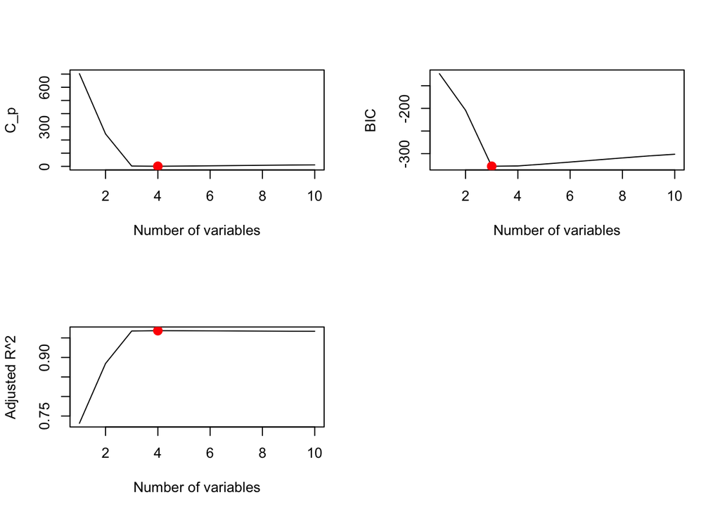

```r
library(leaps)
data.full = data.frame(Y, X)
regfit.fwd = regsubsets(Y~poly(X,10,raw=T), data=data.frame(Y,X), nvmax=10, method="forward")
summary = summary(regfit.fwd)
par(mfrow=c(2,2))
plot(summary$cp, xlab ="Number of variables", ylab="C_p", type="l")
points(which.min(summary$cp), summary$cp[which.min(summary$cp)], col = "red", cex = 2, pch = 20)
plot(summary$bic, xlab ="Number of variables", ylab="BIC", type="l")
points(which.min(summary$bic), summary$bic[which.min(summary$bic)], col = "red", cex = 2, pch = 20)
plot(summary$adjr2, xlab ="Number of variables", ylab="Adjusted R^2", type="l")
points(which.max(summary$adjr2), summary$adjr2[which.max(summary$adjr2)], col = "red", cex = 2, pch = 20)
```

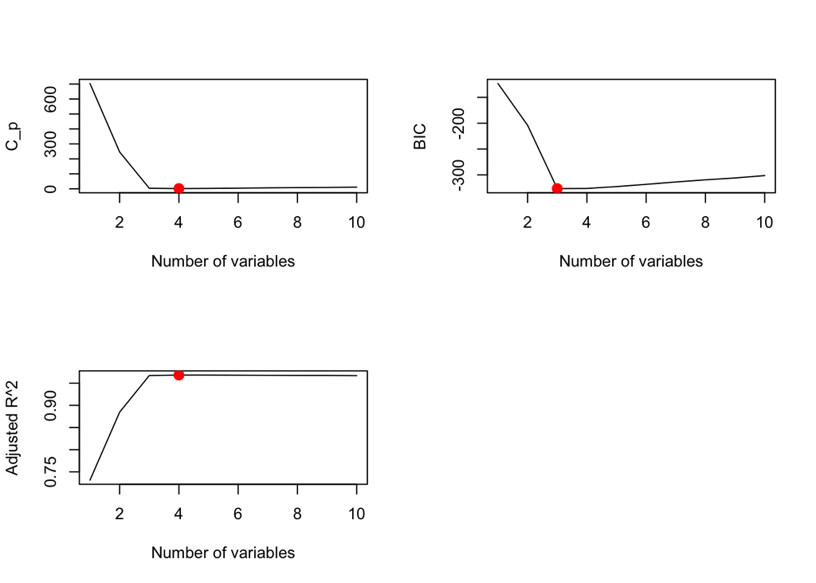

```r
library(leaps)
data.full = data.frame(Y, X)
regfit.back = regsubsets(Y~poly(X,10,raw=T), data=data.frame(Y,X), nvmax=10, method="backward")
summary = summary(regfit.back)
par(mfrow=c(2,2))
plot(summary$cp, xlab ="Number of variables", ylab="C_p", type="l")
points(which.min(summary$cp), summary$cp[which.min(summary$cp)], col = "red", cex = 2, pch = 20)
plot(summary$bic, xlab ="Number of variables", ylab="BIC", type="l")
points(which.min(summary$bic), summary$bic[which.min(summary$bic)], col = "red", cex = 2, pch = 20)
plot(summary$adjr2, xlab ="Number of variables", ylab="Adjusted R^2", type="l")
points(which.max(summary$adjr2), summary$adjr2[which.max(summary$adjr2)], col = "red", cex = 2, pch = 20)
```

```r
coef(regfit.full, which.max(summary(regfit.full)$adjr2))
```

```
##           (Intercept) poly(X, 10, raw = T)1 poly(X, 10, raw = T)2
##           -3.92799225            3.38745596           -2.15424359
## poly(X, 10, raw = T)3 poly(X, 10, raw = T)5
##            0.55797426            0.08072292
```

```r
coef(regfit.fwd, which.max(summary(regfit.fwd)$adjr2))
```

```
##           (Intercept) poly(X, 10, raw = T)1 poly(X, 10, raw = T)2
##           -3.92799225            3.38745596           -2.15424359
## poly(X, 10, raw = T)3 poly(X, 10, raw = T)5
##            0.55797426            0.08072292
```

```r
coef(regfit.back, which.max(summary(regfit.back)$adjr2))
```

```
##           (Intercept) poly(X, 10, raw = T)1 poly(X, 10, raw = T)2
##           -3.93986035            3.70201369           -2.13582615
## poly(X, 10, raw = T)5 poly(X, 10, raw = T)7
##            0.30330191           -0.02419389
```